# MPDW Praktikum 67

G1401211094 Hanifa Rahmacindia Nasution

2023-10-16

# Packages

```r
library(rio)
library(ggplot2)
library(tsibble)
library(tseries)
library(MASS)
library(forecast)
library(TSA)
library(TTR)
library(aTSA)
library(graphics)
```

# Input Data

```r
gas <- rio::import("https://raw.githubusercontent.com/HanifaNasution/Praktikum-MPDW/main/Data/Data%20Natural%20Gas%20Imputasi.csv")
View(gas)
str(gas)
```

```
## 'data.frame':    366 obs. of  8 variables:
##  $ Period  : int  1 2 3 4 5 6 7 8 9 10 ...
##  $ Date    : chr  "9/1/2021" "9/2/2021" "9/3/2021" "9/4/2021" ...
##  $ Open    : num  4.4 4.64 4.63 NA 4.73 ...
##  $ High    : num  4.71 4.73 4.72 NA 4.74 ...
##  $ Low     : num  4.38 4.58 4.59 NA 4.71 ...
##  $ Close   : num  4.62 4.64 4.71 NA 4.72 ...
##  $ Volume  : int  241159 176845 110953 NA NA NA 163663 244742 234848 151036 ...
##  $ Currency: chr  "USD" "USD" "USD" "USD" ...
```

```r
dim(gas)
```

```
## [1] 366   8
```

Ubah data tanggal ke mode “date”

```r
library(dplyr)
library(lubridate)
library(stringr)
gas_clean <- gas %>%
  mutate(Date = mdy(Date))
str(gas_clean)
```

```
## 'data.frame':    366 obs. of  8 variables:
##  $ Period  : int  1 2 3 4 5 6 7 8 9 10 ...
##  $ Date    : Date, format: "2021-09-01" "2021-09-02" ...
##  $ Open    : num  4.4 4.64 4.63 NA 4.73 ...
##  $ High    : num  4.71 4.73 4.72 NA 4.74 ...
##  $ Low     : num  4.38 4.58 4.59 NA 4.71 ...
##  $ Close   : num  4.62 4.64 4.71 NA 4.72 ...
##  $ Volume  : int  241159 176845 110953 NA NA NA 163663 244742 234848 151036 ...
##  $ Currency: chr  "USD" "USD" "USD" "USD" ...
```

Tampak bahwa kolom tanggal telah menggunakan mode “Date” bukan “chr” lagi

# Imputasi Data Hilang

```r
library(imputeTS)
```

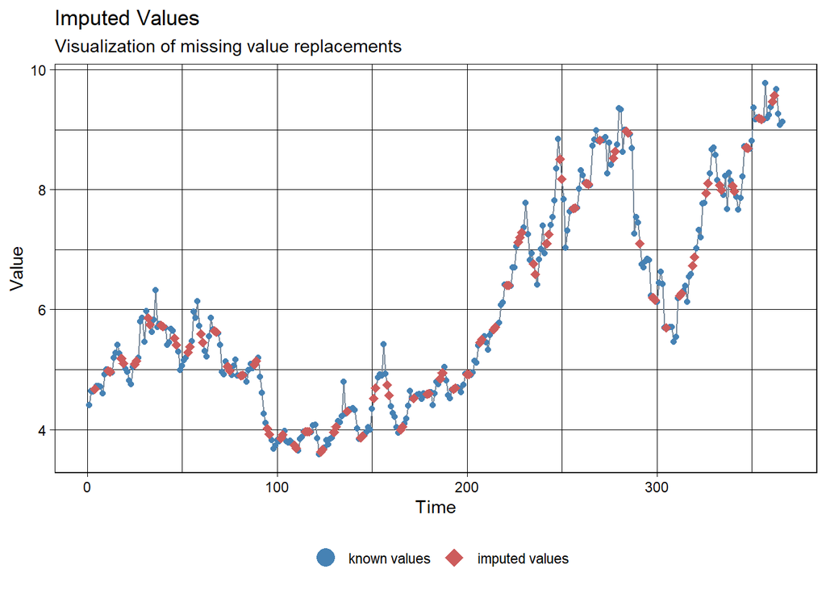

```r
gas.open<- na_interpolation(gas_clean$Open)
ggplot_na_imputations(gas_clean$Open,gas.open)
```

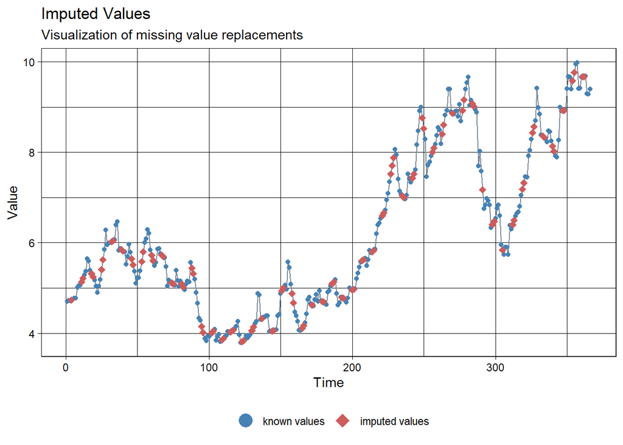

```r
gas.high<- na_interpolation(gas_clean$High)
ggplot_na_imputations(gas_clean$High,gas.high)
```

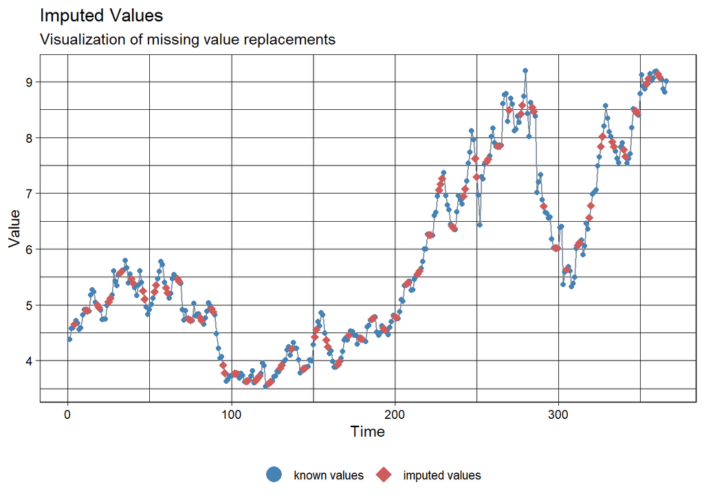

```r
gas.low<- na_interpolation(gas_clean$Low)
ggplot_na_imputations(gas_clean$Low,gas.low)
```

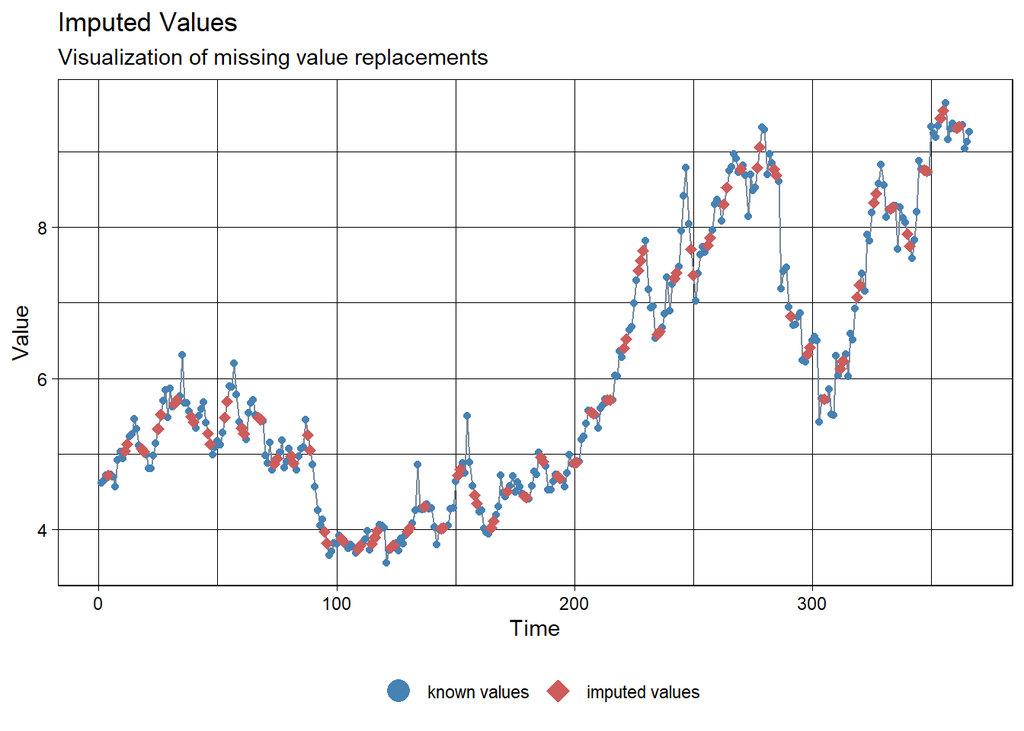

```r
gas.close <- na_interpolation(gas_clean$Close)
ggplot_na_imputations(gas_clean$Close,gas.close)
```

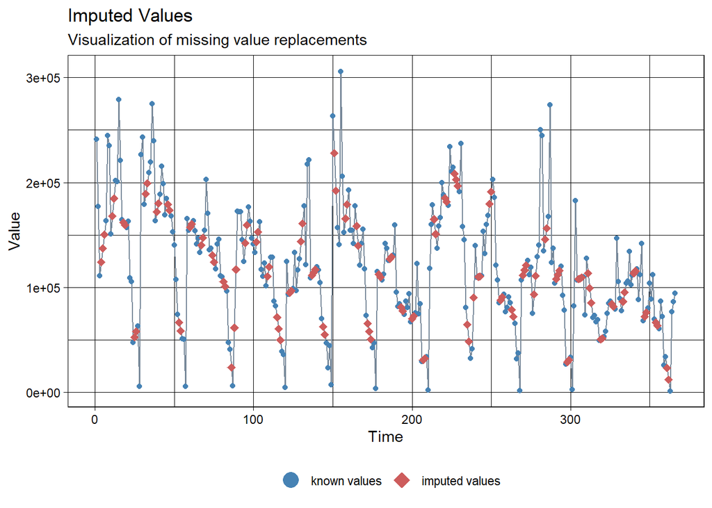

```r
gas.volume <- na_interpolation(gas_clean$Volume)
ggplot_na_imputations(gas_clean$Volume,gas.volume)
```

# Data Penuh Pasca Imputasi

```r
gas.imp <- data.frame(gas_clean$Period,gas_clean$Date,cbind(gas.open,gas.high,gas.low,gas.close,gas.volume),gas_clean$Currency)
View(gas.imp)
str(gas.imp)
```

```
## 'data.frame':    366 obs. of  8 variables:
##  $ gas_clean.Period  : int  1 2 3 4 5 6 7 8 9 10 ...
##  $ gas_clean.Date    : Date, format: "2021-09-01" "2021-09-02" ...
##  $ gas.open          : num  4.4 4.64 4.63 4.68 4.73 ...
##  $ gas.high          : num  4.71 4.73 4.72 4.73 4.74 ...
##  $ gas.low           : num  4.38 4.58 4.59 4.65 4.71 ...
##  $ gas.close         : num  4.62 4.64 4.71 4.72 4.72 ...
##  $ gas.volume        : num  241159 176845 110953 124131 137308 ...
##  $ gas_clean.Currency: chr  "USD" "USD" "USD" "USD" ...
```

```r
summary(gas.imp)
```

```
##  gas_clean.Period gas_clean.Date          gas.open        gas.high
##  Min.   :  1.00   Min.   :2021-09-01   Min.   :3.589   Min.   :3.794
##  1st Qu.: 92.25   1st Qu.:2021-12-01   1st Qu.:4.661   1st Qu.:4.794
##  Median :183.50   Median :2022-03-02   Median :5.484   Median :5.710
##  Mean   :183.50   Mean   :2022-03-02   Mean   :5.969   Mean   :6.193
##  3rd Qu.:274.75   3rd Qu.:2022-06-01   3rd Qu.:7.306   3rd Qu.:7.678
##  Max.   :366.00   Max.   :2022-09-01   Max.   :9.780   Max.   :9.987
##     gas.low        gas.close       gas.volume     gas_clean.Currency
##  Min.   :3.536   Min.   :3.561   Min.   :  1200   Length:366
##  1st Qu.:4.522   1st Qu.:4.684   1st Qu.: 78878   Class :character
##  Median :5.349   Median :5.503   Median :115310   Mode  :character
##  Mean   :5.776   Mean   :5.981   Mean   :119401
##  3rd Qu.:7.045   3rd Qu.:7.384   3rd Qu.:157808
##  Max.   :9.200   Max.   :9.647   Max.   :305898
```

Pada peramalan ini hanya digunakan data saham ketika mencapai nilai tertinggi, yaitu data saham kolom high

# Eksplorasi Data

## Plot Deret Waktu Data Penuh

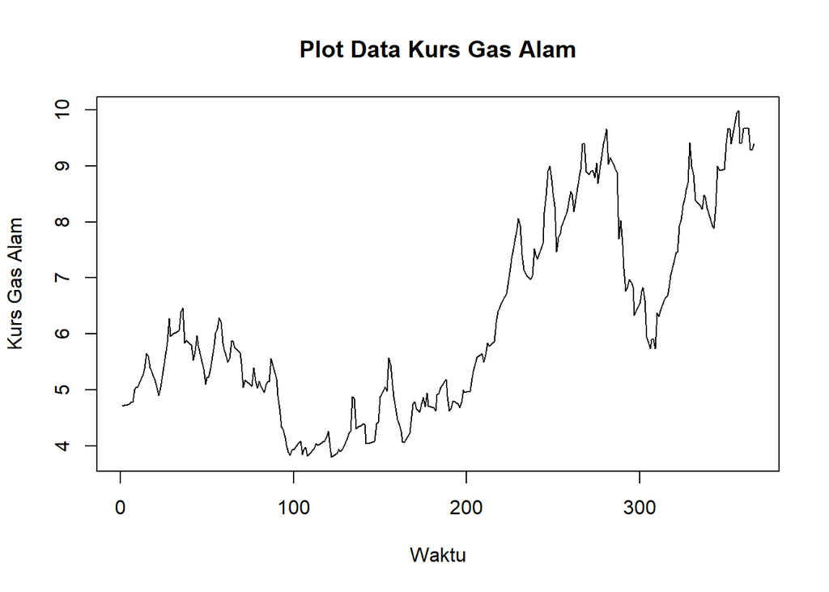

```r
gas.high.ts <- ts(gas.high)
plot(gas.high.ts, lty=1, xlab="Waktu", ylab="Kurs Gas Alam", main="Plot Data Kurs Gas Alam")
```

Berdasarkan plot yang dihasilkan data penuh dicoba untuk memotong data dengan ketentuan 80% data latih dan 20% data uji.

### Pembagian Data Latih dan Data Uji (Percobaan 1)

Data Latih 80% data awal Data Uji 20% data awal

```r
gas.train <- gas.high[1:293]
gas.test <- gas.high[294:366]

gas.train.ts <- ts(gas.train)
gas.test.ts <- ts(gas.test)
```

### Plot Deret waktu Data Latih (Percobaan 1)

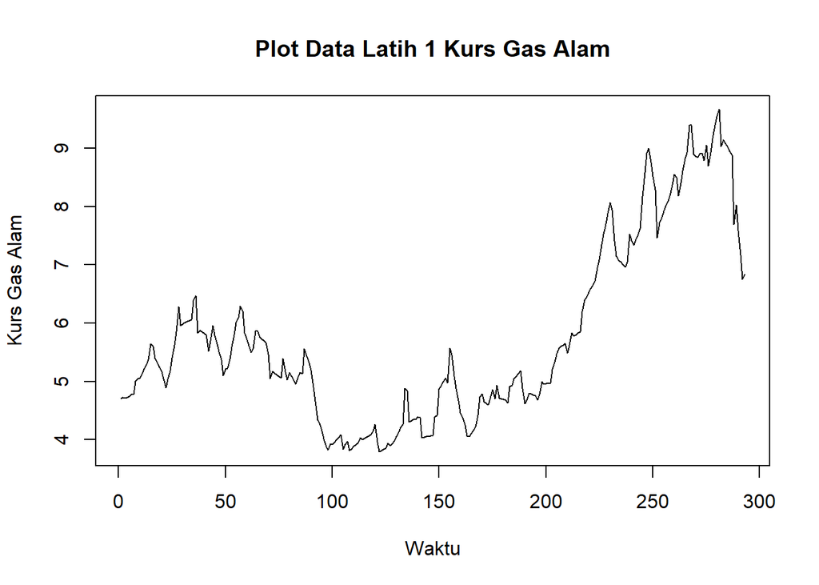

```r
plot(gas.train.ts, lty=1, xlab="Waktu", ylab="Kurs Gas Alam", main="Plot Data Latih 1 Kurs Gas Alam")
```

Berdasarkan plot deret waktu data latih saham gas alam tampak bahwa data cenderung memiliki trend naik dan tidak bergerak dalam satu angka tertentu sehingga data latih tidak stasioner baik dalam rataan maupun ragam Namun, pemotongan ini tidak tepat karena akan memotong data ketika akan naik setelah data turun sehingga disinyalir akan memberikan peramalan yang kurang tepat sehingga harus dicoba pembagian data lainnya

## Pembagian Data Latih dan Data Uji (Percobaan 2)

Data Latih 86% data awal Data Uji 14% data awal

```r
gas.train <- gas.high[1:315]
gas.test <- gas.high[316:366]

gas.high.ts <- ts(gas.high)
gas.train.ts <- ts(gas.train)
gas.test.ts <- ts(gas.test)
```

## Plot Deret waktu Data Latih (Percobaan 2)

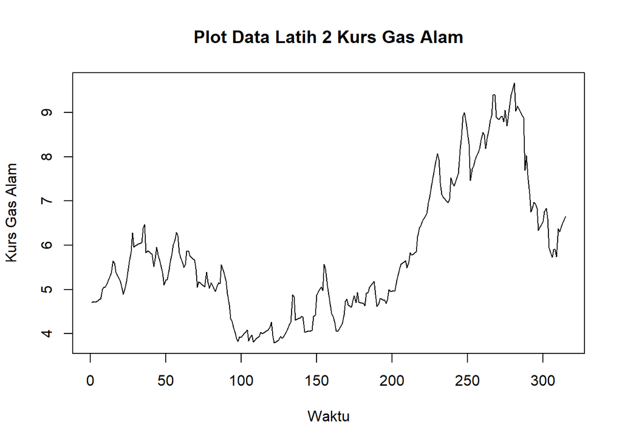

```r
plot(gas.train.ts, lty=1, xlab="Waktu", ylab="Kurs Gas Alam", main="Plot Data Latih 2 Kurs Gas Alam")
```

Berdasarkan plot deret waktu data latih saham gas alam tampak bahwa data cenderung memiliki trend naik dan tidak bergerak dalam satu angka tertentu sehingga data latih tidak stasioner baik dalam rataan maupun ragam Pemotongan ini dianggap lebih baik karena memotong data ketika data aktual akan naik terus sehingga disinyalir hasil peramalan akan lebih baik nantinya

## Plot Deret Waktu Data Uji

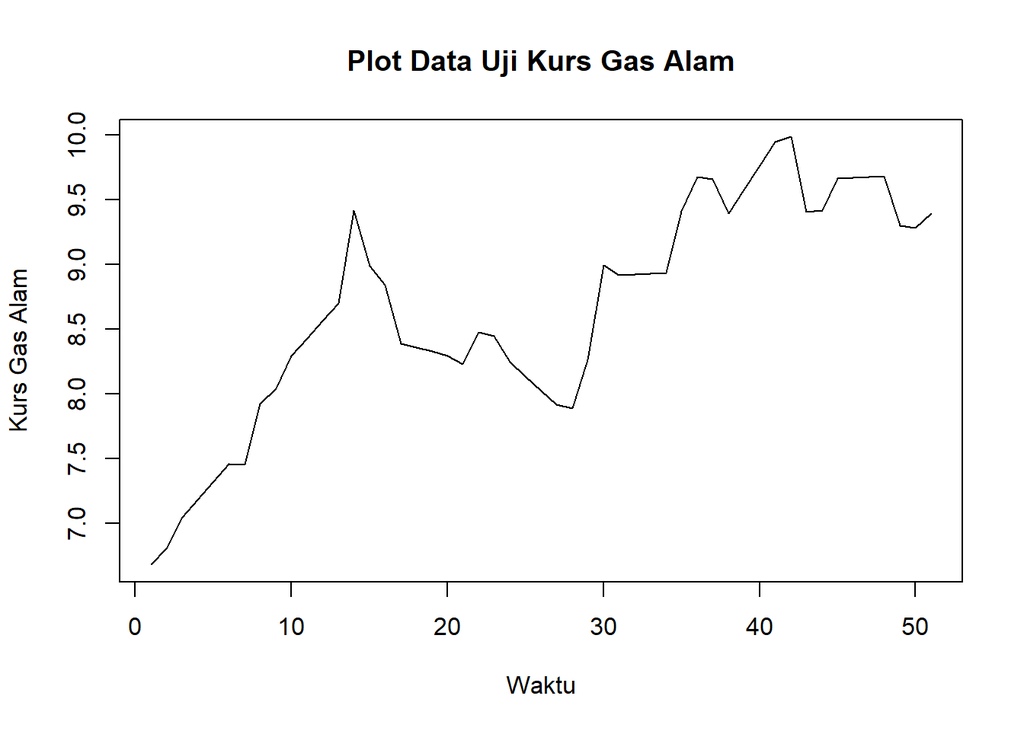

```r
plot(gas.test.ts, lty=1, xlab="Waktu", ylab="Kurs Gas Alam", main="Plot Data Uji Kurs Gas Alam")
```

# Uji Stasioneritas Data

## Plot ACF

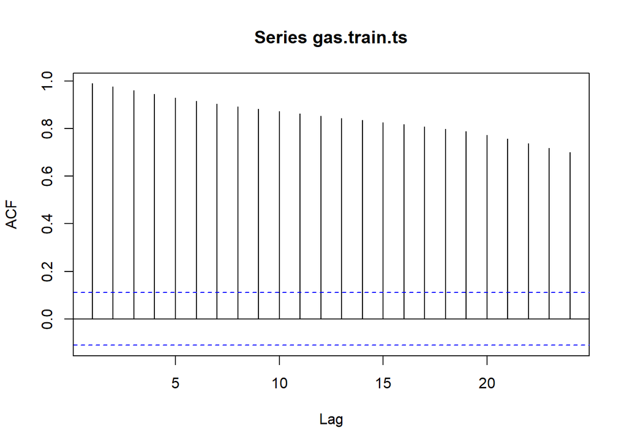

```r
acf(gas.train.ts)
```

Berdasarkan plot ACF data latih kurs gas alam, tampak bahwa plot ACF *tails off slowly*. Hal ini menandakan bahwa data latih kurs gas alam tidak stasioner dalam rataan.

## Uji ADF

```r
tseries::adf.test(gas.train.ts)
```

```
##
##  Augmented Dickey-Fuller Test
##
## data:  gas.train.ts
## Dickey-Fuller = -1.6785, Lag order = 6, p-value = 0.712
## alternative hypothesis: stationary
```

$H_0$ : Data tidak stasioner dalam rataan

$H_1$ : Data stasioner dalam rataan

Berdasarkan uji ADF tersebut, didapat *p-value* sebesar 0.712 yang lebih besar dari taraf nyata 5% sehingga tak tolak $H_0$ dan menandakan bahwa data tidak stasioner dalam rataan. Hal ini sesuai dengan hasil eksplorasi menggunakan plot time series dan plot ACF, sehingga ketidakstasioneran model kedepannya harus ditangani

## Plot Box-Cox

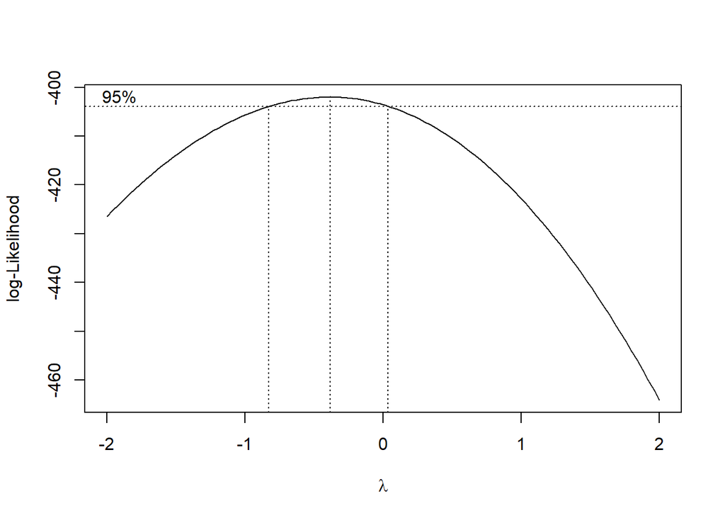

```r
index <- seq(1:315)
bc = boxcox(gas.train.ts~index, lambda = seq(-2,2,by=1))
```

```r
#Nilai Rounded Lambda
lambda <- bc$x[which.max(bc$y)]
lambda
```

```
## [1] -0.3838384
```

```r
#SK
bc$x[bc$y > max(bc$y) - 1/2 * qchisq(.95,1)]
```

```
##  [1] -0.78787879 -0.74747475 -0.70707071 -0.66666667 -0.62626263 -0.58585859
##  [7] -0.54545455 -0.50505051 -0.46464646 -0.42424242 -0.38383838 -0.34343434
## [13] -0.30303030 -0.26262626 -0.22222222 -0.18181818 -0.14141414 -0.10101010
## [19] -0.06060606 -0.02020202  0.02020202
```

Plot Boxcox menunjukkan nilai *rounded value* ($\lambda$) optimum sebesar **-0,3838384** dan pada selang kepercayaan 95% nilai memiliki batas bawah **-0,7878789** dan batas atas **0,020202**. Selang tersebut tidak memuat nilai satu sehingga dapat dikatakan bahwa data latih kurs gas alam tidak stasioner dalam ragam.

# Penanganan Ketidakstasioneran Data

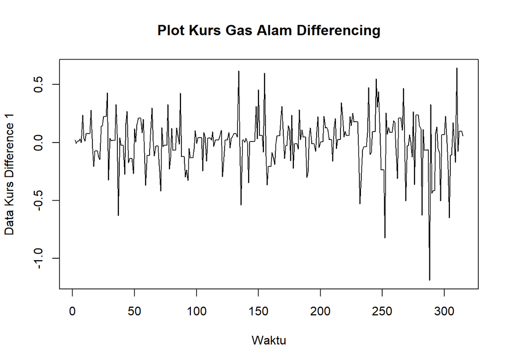

```r
gas.train.diff<-diff(gas.train.ts,differences = 1)
plot.ts(gas.train.diff, lty=1, xlab="Waktu", ylab="Data Kurs Difference 1", main="Plot Kurs Gas Alam Differencing")
```

Berdasarkan plot data deret waktu, terlihat bahwa data sudah mulai tampak stasioner dalam rataan ditandai dengan data bergerak pada nilai tengah tertentu (tidak terdapat trend ataupun musiman pada data)

## Plot ACF

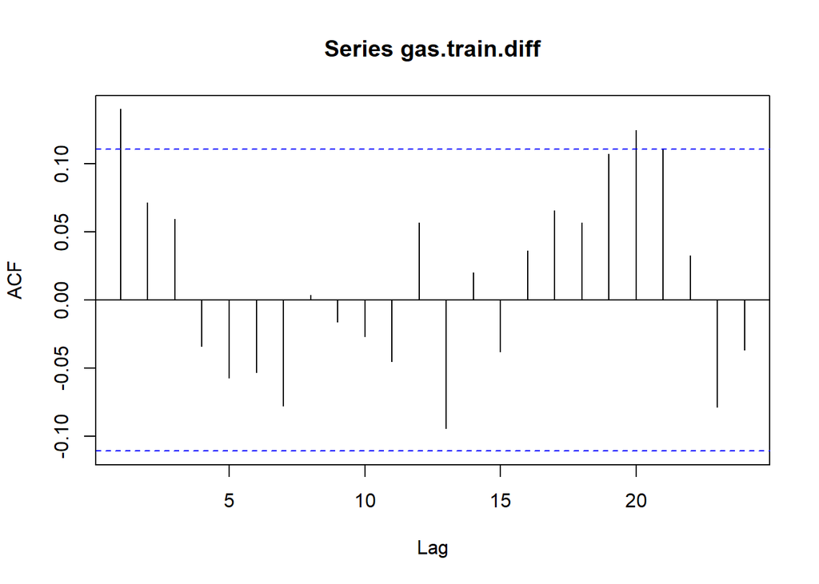

```r
acf(gas.train.diff)
```

Berdasarkan plot tersebut, terlihat bahwa plot ACF cuts off pada lag ke 1. Hal ini menandakan data sudah stasioner dalam rataan dan ketidakstasioneran data telah berhasil tertangani.

#### Uji ADF

```r
tseries::adf.test(gas.train.diff)
```

```
##
##  Augmented Dickey-Fuller Test
##
## data:  gas.train.diff
## Dickey-Fuller = -7.1758, Lag order = 6, p-value = 0.01
## alternative hypothesis: stationary
```

$H_0$ : Data tidak stasioner dalam rataan

$H_1$ : Data stasioner dalam rataan

Berdasarkan uji ADF tersebut, didapat *p-value* sebesar 0.01 yang lebih kecil dari taraf nyata 5% sehingga tolak $H_0$ atau data stasioner dalam rataan. Hal ini sesuai dengan hasil eksplorasi menggunakan plot time series dan plot ACF pasca differencing, sehingga dalam hal ini ketidakstasioneran data sudah berhasil ditangani dan dapat dilanjutkan ke pemodelan

# Identifikasi Model

## Plot ACF

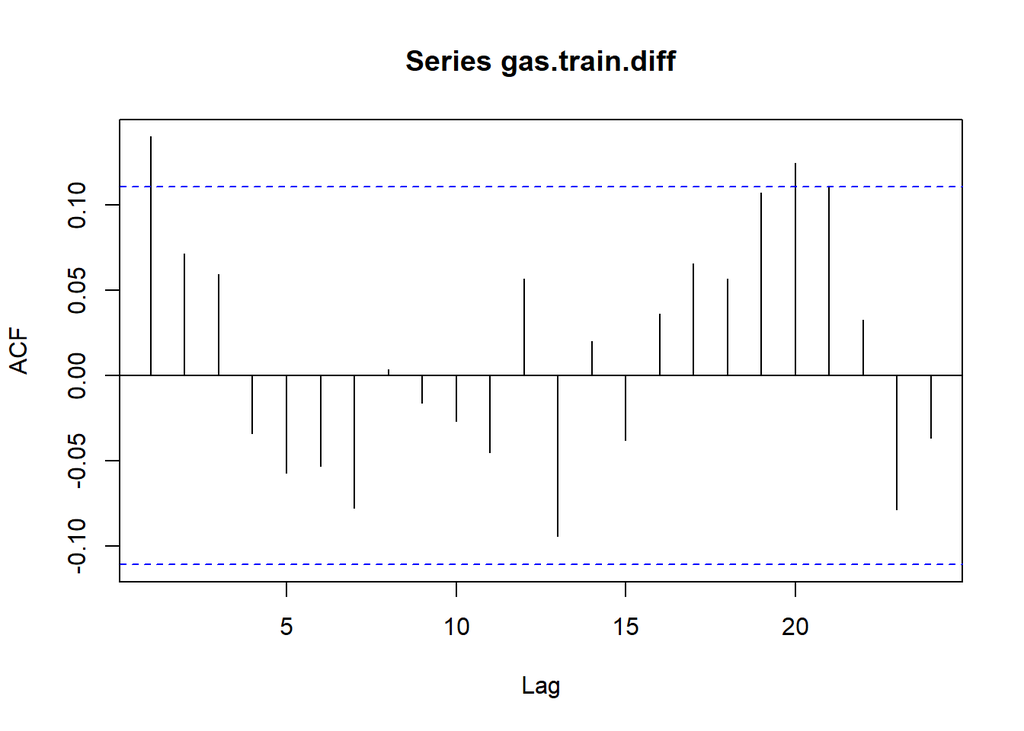

```r
acf(gas.train.diff)
```

Berdasarkan plot tersebut, terlihat bahwa plot ACF cenderung *cuts off* pada lag ke 1 dan jika plot PACF dianggap *tails of*, maka model tentatifnya adalah ARIMA(0,1,1).

## Plot PACF

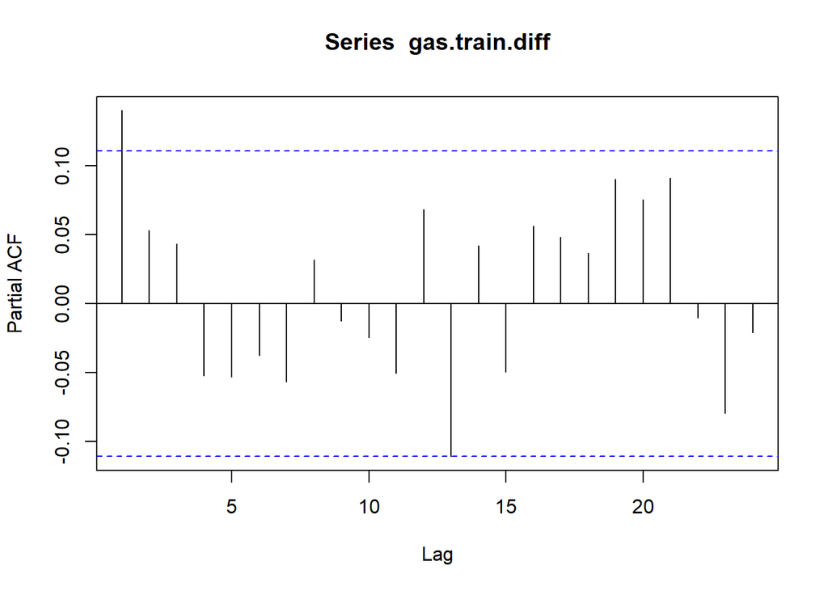

```r
pacf(gas.train.diff)
```

Berdasarkan plot tersebut, terlihat bahwa plot PACF cenderung *cuts off* pada lag ke 1, sehingga jika plot ACF dianggap *tails of*, maka model tentatifnya adalah ARIMA(1,1,0).

Jika baik plot ACF maupun plot PACF keduanya dianggap tails of, maka model yang terbentuk adalah ARIMA(1,1,1)

## Plot EACF

```r
eacf(gas.train.diff)
```

```
## AR/MA
##   0 1 2 3 4 5 6 7 8 9 10 11 12 13
## 0 x o o o o o o o o o o  o  o  o
## 1 x o o o o o o o o o o  o  o  o
## 2 x x o o o o o o o o o  o  o  o
## 3 x x x o o o o o o o o  o  o  o
## 4 x o x x o o o o o o o  o  o  o
## 5 x x o x o o o o o o o  o  o  o
## 6 x x o x x o o o o o o  o  o  o
## 7 x o x x o x o o o o o  o  o  o
```

Identifikasi model menggunakan plot EACF dilakukan dengan melihat ujung segitiga pada pola segitiga nol. Dalam hal ini model tentatif yang terbentuk adalah ARIMA(0,1,1), ARIMA(1,1,1), ARIMA(2,1,2), dan ARIMA(3,1,3).

Berdasarkan model yang didapat dari plot ACF, PACF, dan EACF didapat 5 model tentatif, yaitu ARIMA (1,1,0), ARIMA(0,1,1), ARIMA(1,1,1), ARIMA(2,1,2), dan ARIMA(3,1,3).

# Pendugaan Parameter Model Tentatif

## ARIMA(0,1,1)

```r
model1=Arima(gas.train.diff, order=c(0,1,1),method="ML")
summary(model1) #AIC=-78.97
```

```
## Series: gas.train.diff
## ARIMA(0,1,1)
##
## Coefficients:
##           ma1
##       -1.0000
## s.e.   0.0143
##
## sigma^2 = 0.04424:  log likelihood = 41.48
## AIC=-78.97   AICc=-78.93   BIC=-71.48
##
## Training set error measures:
##                        ME      RMSE       MAE  MPE MAPE      MASE      ACF1
## Training set -0.003126911 0.2096627 0.1433882 -Inf  Inf 0.8499932 0.1399336
```

```r
lmtest::coeftest(model1) #seluruh parameter signifikan
```

```
##
## z test of coefficients:
##
##     Estimate Std. Error z value  Pr(>|z|)
## ma1 -1.00000    0.01432 -69.834 < 2.2e-16 ***
## ---
## Signif. codes:  0 '***' 0.001 '**' 0.01 '*' 0.05 '.' 0.1 ' ' 1
```

## ARIMA(1,1,0)

```r
model2=Arima(gas.train.diff, order=c(1,1,0),method="ML")
summary(model2) #AIC=10.7
```

```
## Series: gas.train.diff
## ARIMA(1,1,0)
##
## Coefficients:
##           ar1
##       -0.4589
## s.e.   0.0501
##
## sigma^2 = 0.05996:  log likelihood = -3.35
## AIC=10.7   AICc=10.73   BIC=18.19
##
## Training set error measures:
##                        ME      RMSE       MAE  MPE MAPE      MASE       ACF1
## Training set 0.0002335151 0.2440907 0.1616892 -Inf  Inf 0.9584801 -0.1439141
```

```r
lmtest::coeftest(model2) #seluruh parameter signifikan
```

```
##
## z test of coefficients:
##
##     Estimate Std. Error z value  Pr(>|z|)
## ar1 -0.45889    0.05008  -9.163 < 2.2e-16 ***
## ---
## Signif. codes:  0 '***' 0.001 '**' 0.01 '*' 0.05 '.' 0.1 ' ' 1
```

## ARIMA(1,1,1)

```r
model3=Arima(gas.train.diff, order=c(1,1,1),method="ML")
summary(model3) #AIC=-83.45
```

```
## Series: gas.train.diff
## ARIMA(1,1,1)
##
## Coefficients:
##          ar1      ma1
##       0.1429  -1.0000
## s.e.  0.0560   0.0114
##
## sigma^2 = 0.04351:  log likelihood = 44.72
## AIC=-83.45   AICc=-83.37   BIC=-72.21
##
## Training set error measures:
##                        ME      RMSE       MAE  MPE MAPE      MASE       ACF1
## Training set -0.002663764 0.2075992 0.1408843 -Inf  Inf 0.8351508 -0.0104734
```

```r
lmtest::coeftest(model3) #seluruh parameter signifikan
```

```
##
## z test of coefficients:
##
##      Estimate Std. Error  z value Pr(>|z|)
## ar1  0.142868   0.055988   2.5518  0.01072 *
## ma1 -0.999999   0.011378 -87.8871  < 2e-16 ***
## ---
## Signif. codes:  0 '***' 0.001 '**' 0.01 '*' 0.05 '.' 0.1 ' ' 1
```

## ARIMA(2,1,2)

```r
model4=Arima(gas.train.diff, order=c(2,1,2),method="ML")
summary(model4) #AIC=-80.65
```

```
## Series: gas.train.diff
## ARIMA(2,1,2)
##
## Coefficients:
##          ar1     ar2      ma1     ma2
##       0.3584  0.0282  -1.2242  0.2242
## s.e.  0.4425  0.0892   0.4398  0.4397
##
## sigma^2 = 0.04365:  log likelihood = 45.32
## AIC=-80.65   AICc=-80.45   BIC=-61.91
##
## Training set error measures:
##                        ME      RMSE       MAE  MPE MAPE      MASE         ACF1
## Training set -0.002381824 0.2072526 0.1393907 -Inf  Inf 0.8262969 -0.003272745
```

```r
lmtest::coeftest(model4) #hanya parameter ma1 signifikan
```

```
##
## z test of coefficients:
##
##      Estimate Std. Error z value Pr(>|z|)
## ar1  0.358376   0.442540  0.8098 0.418045
## ar2  0.028190   0.089168  0.3161 0.751894
## ma1 -1.224152   0.439834 -2.7832 0.005382 **
## ma2  0.224152   0.439711  0.5098 0.610211
## ---
## Signif. codes:  0 '***' 0.001 '**' 0.01 '*' 0.05 '.' 0.1 ' ' 1
```

## ARIMA(3,1,3)

```r
model5=Arima(gas.train.diff, order=c(3,1,3),method="ML")
summary(model5) #AIC=-77.67
```

```
## Series: gas.train.diff
## ARIMA(3,1,3)
##
## Coefficients:
##           ar1      ar2    ar3      ma1      ma2      ma3
##       -0.2829  -0.1679  0.113  -0.5821  -0.1432  -0.2747
## s.e.   1.1341   0.6188  0.127   1.1434   0.6977   0.7212
##
## sigma^2 = 0.04379:  log likelihood = 45.84
## AIC=-77.67   AICc=-77.31   BIC=-51.45
##
## Training set error measures:
##                        ME      RMSE       MAE  MPE MAPE      MASE         ACF1
## Training set -0.002368479 0.2069087 0.1393582 -Inf  Inf 0.8261039 -0.003150472
```

```r
lmtest::coeftest(model5) #tidak ada parameter signifikan
```

```
##
## z test of coefficients:
##
##     Estimate Std. Error z value Pr(>|z|)
## ar1 -0.28294    1.13411 -0.2495   0.8030
## ar2 -0.16790    0.61876 -0.2713   0.7861
## ar3  0.11304    0.12699  0.8901   0.3734
## ma1 -0.58212    1.14336 -0.5091   0.6107
## ma2 -0.14322    0.69765 -0.2053   0.8374
## ma3 -0.27466    0.72120 -0.3808   0.7033
```

Berdasarkan pendugaan parameter di atas, nilai AIC terkecil dimiliki oleh model ARIMA(1,1,1) dan parameter model ARIMA(1,1,1) juga seluruhnya signifikan sehingga model yang dipilih adalah model ARIMA(1,1,1).

# Analisis Sisaan

Model terbaik hasil identifikasi kemudian dicek asumsi sisaannya. Sisaan model ARIMA harus memenuhi asumsi normalitas, kebebasan, dan kehomogenan ragam. Diagnostik model dilakukan secara eksplorasi dan uji formal.

## Eksplorasi Sisaan

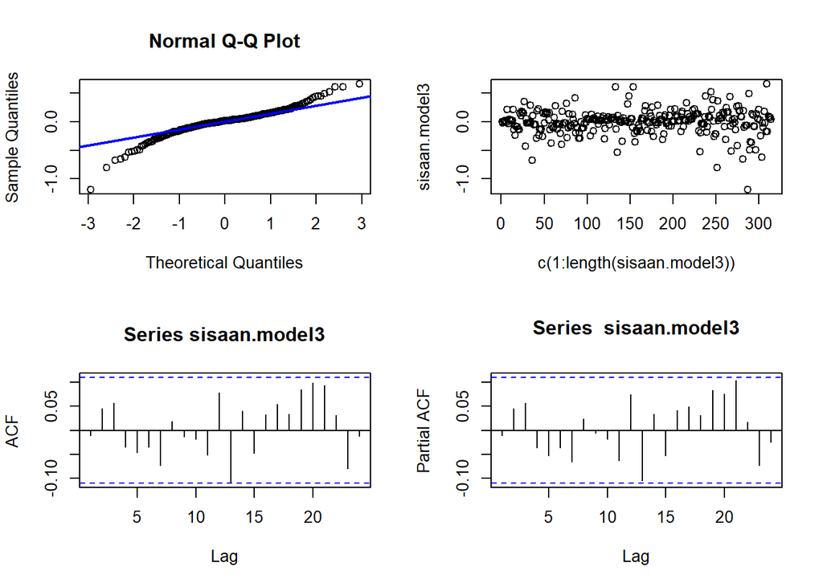

```r
#Eksplorasi
sisaan.model3 <- model3$residuals
par(mfrow=c(2,2))
qqnorm(sisaan.model3)
qqline(sisaan.model3, col = "blue", lwd = 2)
plot(c(1:length(sisaan.model3)),sisaan.model3)
acf(sisaan.model3)
pacf(sisaan.model3)
```

```r
par(mfrow = c(1,1))
```

Berdasarkan plot kuantil-kuantil normal, secara eksplorasi ditunjukkan sisaan tidak menyebar normal karena tidak mengikuti garis $45^{\circ}$ secara penuh. Kemudian dapat dilihat juga lebar pita sisaan yang tidak sama menandakan bahwa sisaan memiliki ragam yang tidak homogen. Selain itu, plot ACF dan PACF sisaan ARIMA(1,1,1) signifikan pada lag ke-13 sehingga sisaan tidak saling bebas. Kondisi ini akan diuji lebih lanjut dengan uji formal.

## Uji Formal

```r
#1) Sisaan Menyebar Normal
ks.test(sisaan.model3,"pnorm")
```

```
##
##  Asymptotic one-sample Kolmogorov-Smirnov test
##
## data:  sisaan.model3
## D = 0.3376, p-value < 2.2e-16
## alternative hypothesis: two-sided
```

```r
#tolak H0 > sisaan tidak menyebar normal
```

Selain dengan eksplorasi, asumsi tersebut dapat diuji menggunakan uji formal. Pada tahapan ini uji formal yang digunakan untuk normalitas adalah uji Kolmogorov-Smirnov (KS). Hipotesis pada uji KS adalah sebagai berikut.

$H_0$ : Sisaan menyebar normal

$H_1$ : Sisaan tidak menyebar normal

Berdasarkan uji KS tersebut, didapat *p-value* sebesar 2.2e-16 yang lebih kecil dari taraf nyata 5% sehingga tolak $H_0$ dan menandakan bahwa sisaan tidak menyebar normal. Hal ini sesuai dengan hasil eksplorasi menggunakan plot kuantil-kuantil normal.

```r
#2) Sisaan saling bebas/tidak ada autokorelasi
Box.test(sisaan.model3, type = "Ljung")
```

```
##
##  Box-Ljung test
##
## data:  sisaan.model3
## X-squared = 0.034773, df = 1, p-value = 0.8521
```

```r
#tak tolak H0 > sisaan saling bebas
```

Selanjutnya akan dilakukan uji formal untuk kebebasan sisaan menggunakan uji Ljung-Box. Hipotesis yang digunakan adalah sebagai berikut.

$H_0$ : Sisaan saling bebas

$H_1$ : Sisaan tidak tidak saling bebas

Berdasarkan uji Ljung-Box tersebut, didapat *p-value* sebesar 0.8521 yang lebih besar dari taraf nyata 5% sehingga tak tolak $H_0$ dan menandakan bahwa sisaan saling bebas. Hal ini berbeda dengan eksplorasi.

```r
#3) Sisaan homogen
Box.test((sisaan.model3)^2, type = "Ljung")
```

```
##
##  Box-Ljung test
##
## data:  (sisaan.model3)^2
## X-squared = 2.1754, df = 1, p-value = 0.1402
```

```r
#tak tolak H0 > sisaan homogen
```

Hipotesis yang digunakan untuk uji kehomogenan ragam adalah sebagai berikut.

$H_0$ : Ragam sisaan homogen

$H_1$ : Ragam sisaan tidak homogen

Berdasarkan uji Ljung-Box terhadap sisaan kuadrat tersebut, didapat *p-value* sebesar 0.1402 yang lebih besar dari taraf nyata 5% sehingga tak tolak $H_0$ dan menandakan bahwa ragam sisaan homogen. Hal ini berbeda dengan eksplorasi

```r
#4) Nilai tengah sisaan sama dengan nol
t.test(sisaan.model3, mu = 0, conf.level = 0.95)
```

```
##
##  One Sample t-test
##
## data:  sisaan.model3
## t = -0.22703, df = 313, p-value = 0.8206
## alternative hypothesis: true mean is not equal to 0
## 95 percent confidence interval:
##  -0.02574975  0.02042222
## sample estimates:
##    mean of x
## -0.002663764
```

```r
#tak tolak h0 > nilai tengah sisaan sama dengan 0
```

Terakhir, dengan uji-t, akan dicek apakah nilai tengah sisaan sama dengan nol. Hipotesis yang diujikan sebagai berikut.

$H_0$ : nilai tengah sisaan sama dengan 0

$H_1$ : nilai tengah sisaan tidak sama dengan 0

Berdasarkan uji-ttersebut, didapat *p-value* sebesar 0.8206 yang lebih besar dari taraf nyata 5% sehingga tak tolak $H_0$ dan menandakan bahwa nilai tengah sisaan sama dengan nol. Hal ini sesuai dengan eksplorasi.

# Overfitting

Tahapan selanjutnya adalah *overfitting* dilakukan dengan menaikkan orde AR(p) dan MA(q) dari model ARIMA(1,1,1) untuk melihat apakah terdapat model lain yang lebih baik dari model saat ini. Kandidat model *overfitting* adalah ARIMA(2,1,1) dan ARIMA(1,1,2).

```r
#---OVERFITTING---#
model1a.model3=Arima(gas.train.diff, order=c(2,1,1),method="ML")
summary(model1a.model3) #-82.43
```

```
## Series: gas.train.diff
## ARIMA(2,1,1)
##
## Coefficients:
##          ar1     ar2      ma1
##       0.1355  0.0561  -1.0000
## s.e.  0.0564  0.0564   0.0108
##
## sigma^2 = 0.04353:  log likelihood = 45.22
## AIC=-82.43   AICc=-82.3   BIC=-67.45
##
## Training set error measures:
##                        ME      RMSE       MAE  MPE MAPE     MASE        ACF1
## Training set -0.002463106 0.2073082 0.1396672 -Inf  Inf 0.827936 -0.00537233
```

```r
lmtest::coeftest(model1a.model3) #ar2 tidak signifikan
```

```
##
## z test of coefficients:
##
##      Estimate Std. Error  z value Pr(>|z|)
## ar1  0.135528   0.056440   2.4013  0.01634 *
## ar2  0.056070   0.056381   0.9945  0.31999
## ma1 -1.000000   0.010754 -92.9881  < 2e-16 ***
## ---
## Signif. codes:  0 '***' 0.001 '**' 0.01 '*' 0.05 '.' 0.1 ' ' 1
```

```r
model1b.model3=Arima(gas.train.diff, order=c(1,1,2),method="ML")
summary(model1b.model3) #-82.55
```

```
## Series: gas.train.diff
## ARIMA(1,1,2)
##
## Coefficients:
##          ar1      ma1     ma2
##       0.4687  -1.3297  0.3297
## s.e.  0.2330   0.2464  0.2462
##
## sigma^2 = 0.04352:  log likelihood = 45.28
## AIC=-82.55   AICc=-82.43   BIC=-67.57
##
## Training set error measures:
##                      ME      RMSE       MAE  MPE MAPE     MASE         ACF1
## Training set -0.0023891 0.2072814 0.1395654 -Inf  Inf 0.827332 -0.007345763
```

```r
lmtest::coeftest(model1b.model3) #ma2 tidak signifikan
```

```
##
## z test of coefficients:
##
##     Estimate Std. Error z value  Pr(>|z|)
## ar1  0.46866    0.23303  2.0112   0.04431 *
## ma1 -1.32973    0.24642 -5.3961 6.811e-08 ***
## ma2  0.32973    0.24622  1.3392   0.18051
## ---
## Signif. codes:  0 '***' 0.001 '**' 0.01 '*' 0.05 '.' 0.1 ' ' 1
```

```r
#model yang dipilih adalah model awal, yaitu ARIMA(1,1,1)
```

Berdasarkan kedua model hasil *overfitting* di atas, model ARIMA(2,1,1) dan ARIMA(1,1,2) memiliki AIC yang lebih besar dibandingkan dengan model ARIMA(1,1,1) dan parameter kedua model ARIMA(2,1,1) dan ARIMA(1,1,2) tidak seluruhnya signifikan. Oleh karena itu, model ARIMA(1,1,1) akan tetap digunakan untuk melakukan peramalan.

# Peramalan

Peramalan dilakukan menggunakan fungsi `forecast()` . Contoh peramalan berikut ini dilakukan untuk 51 periode ke depan (sebanyak data test).

```r
#---FORECAST---#
ramalan.da <- forecast::forecast(sisaan.model3, h = 51)
ramalan.da
```

```
##     Point Forecast      Lo 80     Hi 80      Lo 95     Hi 95
## 316   -0.002715096 -0.2696069 0.2641767 -0.4108909 0.4054607
## 317   -0.002715096 -0.2696069 0.2641767 -0.4108909 0.4054607
## 318   -0.002715096 -0.2696069 0.2641767 -0.4108909 0.4054607
## 319   -0.002715096 -0.2696069 0.2641767 -0.4108909 0.4054607
## 320   -0.002715096 -0.2696069 0.2641767 -0.4108909 0.4054607
## 321   -0.002715096 -0.2696069 0.2641767 -0.4108909 0.4054607
## 322   -0.002715096 -0.2696069 0.2641767 -0.4108909 0.4054607
## 323   -0.002715096 -0.2696069 0.2641767 -0.4108909 0.4054607
## 324   -0.002715096 -0.2696069 0.2641767 -0.4108909 0.4054607
## 325   -0.002715096 -0.2696069 0.2641767 -0.4108909 0.4054607
## 326   -0.002715096 -0.2696069 0.2641767 -0.4108909 0.4054607
## 327   -0.002715096 -0.2696069 0.2641767 -0.4108909 0.4054607
## 328   -0.002715096 -0.2696069 0.2641767 -0.4108909 0.4054607
## 329   -0.002715096 -0.2696069 0.2641767 -0.4108909 0.4054607
```

[output cut: 37 more lines]

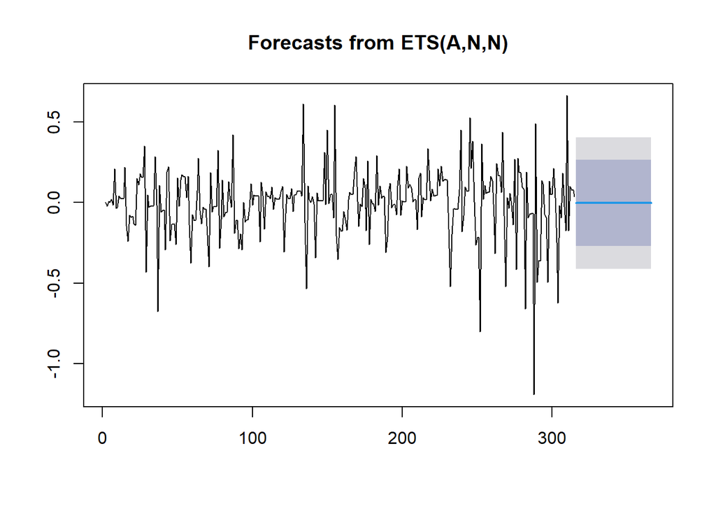

```r
data.ramalan.da <- ramalan.da$mean
plot(ramalan.da)
```

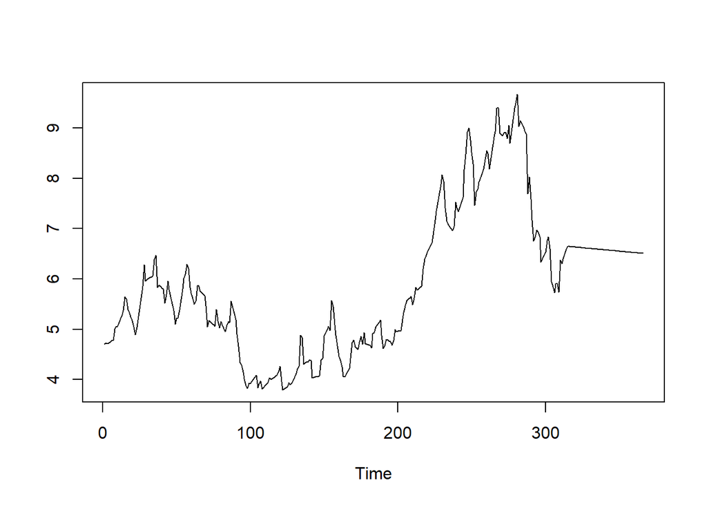

```r
pt_1 <- gas.train.ts[315] #nilai akhir data latih
hasil.forc.Diff <- data.ramalan.da
hasil <- diffinv(hasil.forc.Diff, differences = 1) + pt_1
#has.1 sama hasilnta dengan: cumsum(c(pt_1,hasil.forc.Diff))
ts.plot(gas.train.ts,hasil)
```

```r
perbandingan.da<-matrix(data=c(head(gas.test.ts, n=51), hasil[-1]),
                     nrow = 51, ncol = 2)
colnames(perbandingan.da)<-c("Aktual","Hasil Forecast")
perbandingan.da
```

```
##         Aktual Hasil Forecast
##  [1,] 6.683000       6.644285
##  [2,] 6.806000       6.641570
##  [3,] 7.047000       6.638855
##  [4,] 7.184667       6.636140
##  [5,] 7.322333       6.633425
##  [6,] 7.460000       6.630709
##  [7,] 7.453000       6.627994
##  [8,] 7.925000       6.625279
##  [9,] 8.045000       6.622564
## [10,] 8.293000       6.619849
## [11,] 8.430000       6.617134
## [12,] 8.567000       6.614419
## [13,] 8.704000       6.611704
## [14,] 9.419000       6.608989
```

[output cut: 37 more lines]

```r
accuracy(ts(hasil[-1]), head(gas.test.ts, n=51))
```

```
##                ME     RMSE      MAE      MPE     MAPE      ACF1 Theil's U
## Test set 2.086965 2.267502 2.086965 23.26176 23.26176 0.8988544  8.489344
```

Berdasarkan nilai MAPE yang didapat, yaitu sebesar 23% pada perbandingan nilai forecast dan aktual, dapat disimpulkan bahwa model yang dibangun kurang baik dan kurang sesuai terhadap data gas alam yang digunakan, sehingga perlu mencoba model lain (model selain ARIMA).